# Assignment_2_Meenu_Ravi_part2

I met with prof. Igor Sunday and Thursday for some help.

### Running Midway

This is my mobax terminal showing my notebook started using jnc I ran everything in the compute node and just used the login node for downloading the iris dataset

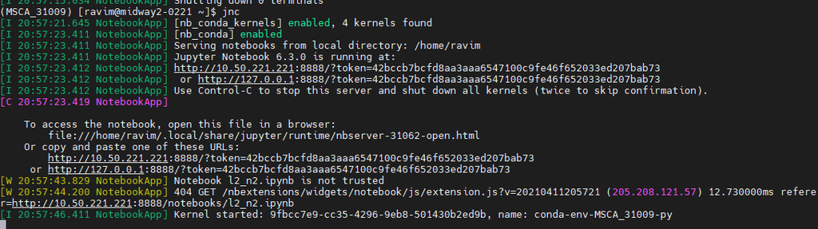

Saving the notebook after running

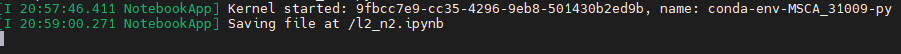

Here is a screenshot of the notebook running in Linux OS and info about the path

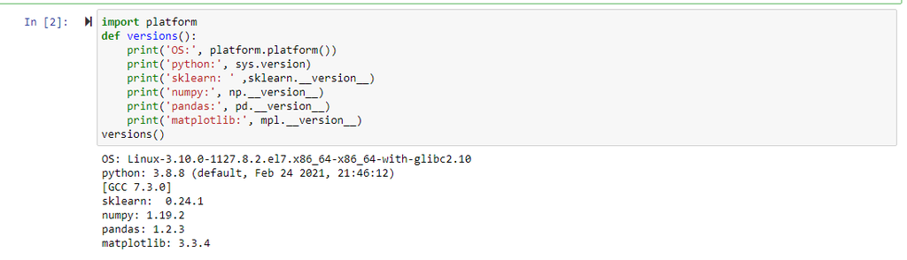

I have attached some screenshots showing the run of the notebook- iris dataset I used the login node for

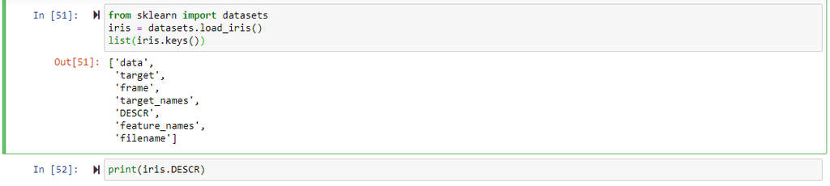

Another screenshot of notebook runs

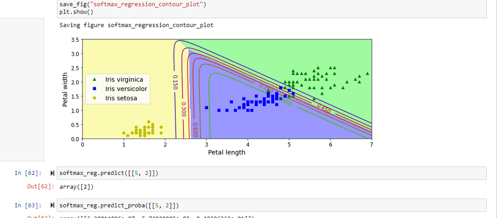

Here you can see I am using the MSCA kernel

[figure not shown]

Here is a screenshot of the image directory with the saved plots

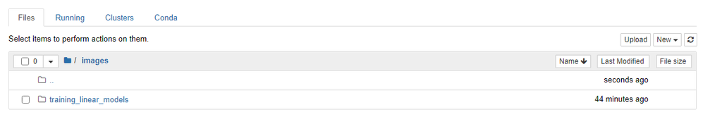

### Running Skyway with Jupyter

Here is my batch file: jupyter.sbatch

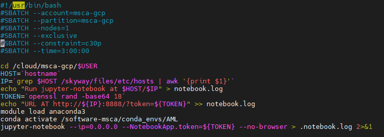

Batch submission

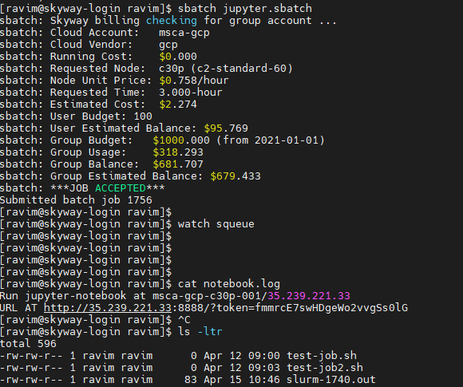

Jupyter notebook with AML kernel

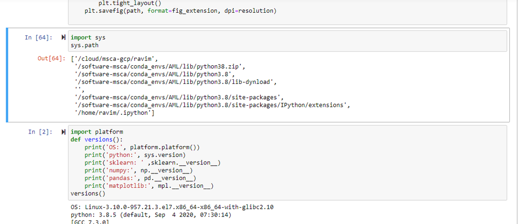

[figure not shown]

### Running Skyway from Python file

Here is my batch file test2.sbatch

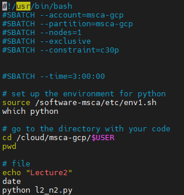

Batch submission

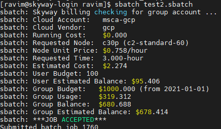

Running the python file:

- Removed matlab line and used:
- import matplotlib as mpl
- mpl.use('Agg') Removed the plt.show lines and saved the figures

Added print statement instead of just outputting as you would on jupyter notebook

Here is a screenshot of my output: the results can be found in slurm-1760.out

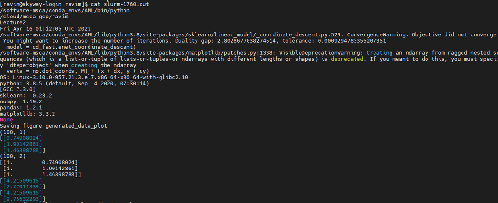

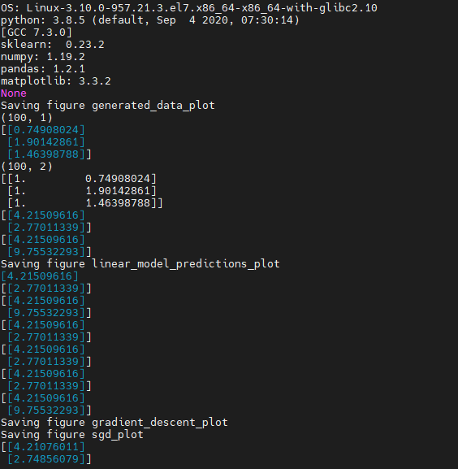

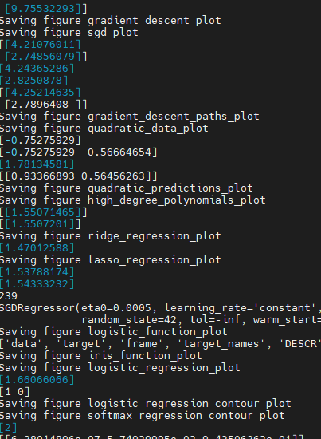

Now I save it as tar file and you can see below my files in the cloud and the tar zip file is in red color

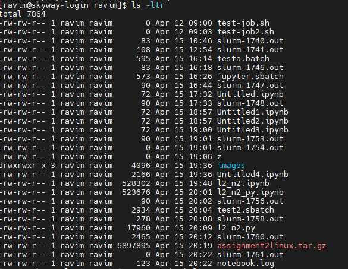

The slurm-1760.out contain the python output

And images are saved in the images directory